# Drug response predict with scDrug

scDrug is a database that can be used to predict the drug sensitivity of single cells based on an existing database of drug responses. In the downstream tasks of single cell analysis, especially in tumours, we are fully interested in potential drugs and combination therapies. To this end, we have integrated scDrug's IC50 prediction and inferCNV to infer the function of tumour cells to build a drug screening pipeline.

Paper: [scDrug: From single-cell RNA-seq to drug response prediction](https://www.sciencedirect.com/science/article/pii/S2001037022005505)

Code: https://github.com/ailabstw/scDrug

Colab_Reproducibility：https://colab.research.google.com/drive/1mayoMO7I7qjYIRjrZEi8r5zuERcxAEcF?usp=sharing

```python
import omicverse as ov
import scanpy as sc
import infercnvpy as cnv
import matplotlib.pyplot as plt
import os

sc.settings.verbosity = 3             # verbosity: errors (0), warnings (1), info (2), hints (3)
sc.settings.set_figure_params(dpi=80, facecolor='white')
```

import omicverse as ov import scanpy as sc import infercnvpy as cnv import matplotlib.pyplot as plt import os sc.settings.verbosity = 3 # verbosity: errors (0), warnings (1), info (2), hints (3) sc.settings.set_figure_params(dpi=80, facecolor='white')

## Infer the Tumor from scRNA-seq

Here we use Infercnvpy's example data to complete the tumour analysis, you can also refer to the official tutorial for this step: https://infercnvpy.readthedocs.io/en/latest/notebooks/tutorial_3k.html

So, we provide a utility function ov.utils.get_gene_annotation to supplement the coordinate information from GTF files. The following usage assumes that the adata.var_names correspond to “gene_name” attribute in the GTF file. For other cases, please check the function documentation.

T2T-CHM13 gtf file can be download from [figshare](https://figshare.com/ndownloader/files/40628072)

```python
adata = cnv.datasets.maynard2020_3k()

ov.utils.get_gene_annotation(
    adata, gtf="gencode.v43.basic.annotation.gtf.gz",
    gtf_by="gene_name"
)
```

adata = cnv.datasets.maynard2020_3k() ov.utils.get_gene_annotation( adata, gtf="gencode.v43.basic.annotation.gtf.gz", gtf_by="gene_name" )

```
try downloading from url
https://github.com/icbi-lab/infercnvpy/releases/download/d0.1.0/maynard2020_3k.h5ad
... this may take a while but only happens once
```

[output not shown]

```python
adata=adata[:,~adata.var['chrom'].isnull()]
adata.var['chromosome']=adata.var['chrom']
adata.var['start']=adata.var['chromStart']
adata.var['end']=adata.var['chromEnd']
adata.var['ensg']=adata.var['gene_id']
adata.var.loc[:, ["ensg", "chromosome", "start", "end"]].head()
```

adata=adata[:,~adata.var['chrom'].isnull()] adata.var['chromosome']=adata.var['chrom'] adata.var['start']=adata.var['chromStart'] adata.var['end']=adata.var['chromEnd'] adata.var['ensg']=adata.var['gene_id'] adata.var.loc[:, ["ensg", "chromosome", "start", "end"]].head()

We noted that infercnvpy need to normalize and log the matrix at first

```python
adata
```

adata

[output not shown]

We use the immune cells as reference and infer the cnv score of each cells in scRNA-seq

```python
# We provide all immune cell types as "normal cells".
cnv.tl.infercnv(
    adata,
    reference_key="cell_type",
    reference_cat=[
        "B cell",
        "Macrophage",
        "Mast cell",
        "Monocyte",
        "NK cell",
        "Plasma cell",
        "T cell CD4",
        "T cell CD8",
        "T cell regulatory",
        "mDC",
        "pDC",
    ],
    window_size=250,
)
cnv.tl.pca(adata)
cnv.pp.neighbors(adata)
cnv.tl.leiden(adata)
cnv.tl.umap(adata)
cnv.tl.cnv_score(adata)
```

# We provide all immune cell types as "normal cells". cnv.tl.infercnv( adata, reference_key="cell_type", reference_cat=[ "B cell", "Macrophage", "Mast cell", "Monocyte", "NK cell", "Plasma cell", "T cell CD4", "T cell CD8", "T cell regulatory", "mDC", "pDC", ], window_size=250, ) cnv.tl.pca(adata) cnv.pp.neighbors(adata) cnv.tl.leiden(adata) cnv.tl.umap(adata) cnv.tl.cnv_score(adata)

```
computing PCA
    with n_comps=50
    finished (0:00:00)
computing neighbors
```

```
OMP: Info #276: omp_set_nested routine deprecated, please use omp_set_max_active_levels instead.
```

```
    finished: added to `.uns['cnv_neighbors']`
    `.obsp['cnv_neighbors_distances']`, distances for each pair of neighbors
    `.obsp['cnv_neighbors_connectivities']`, weighted adjacency matrix (0:00:06)
running Leiden clustering
    finished: found 18 clusters and added
    'cnv_leiden', the cluster labels (adata.obs, categorical) (0:00:00)
computing UMAP
    finished: added
    'X_umap', UMAP coordinates (adata.obsm) (0:00:03)
```

```python
sc.pl.umap(adata, color="cnv_score", show=False)
```

sc.pl.umap(adata, color="cnv_score", show=False)

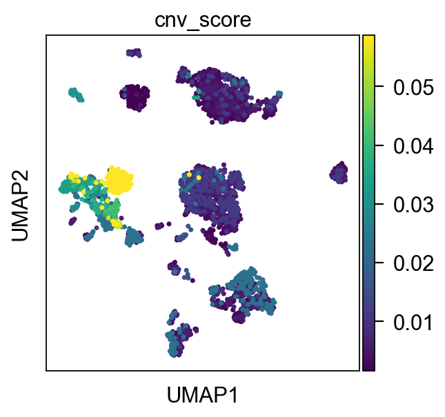

We set an appropriate threshold for the cnv_score, here we set it to 0.03 and identify cells greater than 0.03 as tumour cells

```python
adata.obs["cnv_status"] = "normal"
adata.obs.loc[
    adata.obs["cnv_score"]>0.03, "cnv_status"
] = "tumor"
```

adata.obs["cnv_status"] = "normal" adata.obs.loc[ adata.obs["cnv_score"]>0.03, "cnv_status" ] = "tumor"

```python
sc.pl.umap(adata, color="cnv_status", show=False)
```

sc.pl.umap(adata, color="cnv_status", show=False)

```
... storing 'cnv_status' as categorical
```

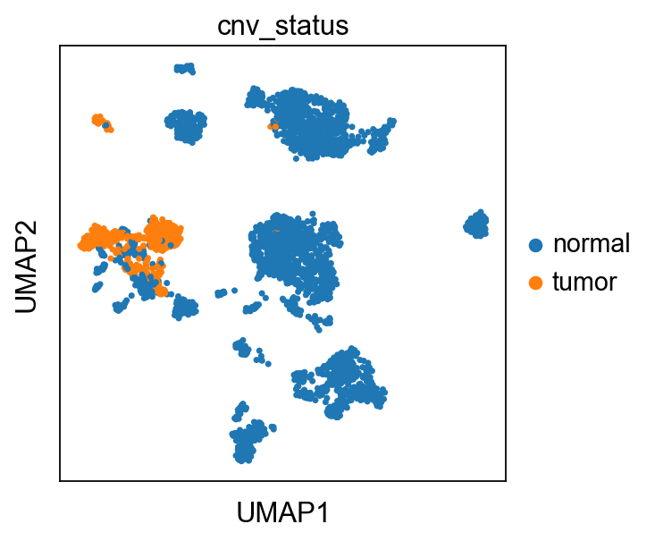

We extracted tumour cells separately for drug prediction response

```python
tumor=adata[adata.obs['cnv_status']=='tumor']
tumor.X.max()
```

tumor=adata[adata.obs['cnv_status']=='tumor'] tumor.X.max()

```
ArrayView(13.09, dtype=float16)
```

## Tumor preprocessing

We need to extract the highly variable genes in the tumour for further analysis, and found out the sub-cluster in tumor

```python
adata=tumor
print('Preprocessing...')
sc.pp.filter_cells(adata, min_genes=200)
sc.pp.filter_genes(adata, min_cells=3)
adata.var['mt'] = adata.var_names.str.startswith('MT-')
sc.pp.calculate_qc_metrics(adata, qc_vars=['mt'], percent_top=None, log1p=False, inplace=True)
if not (adata.obs.pct_counts_mt == 0).all():
    adata = adata[adata.obs.pct_counts_mt < 30, :]

adata.raw = adata.copy()

sc.pp.highly_variable_genes(adata)
adata = adata[:, adata.var.highly_variable]
sc.pp.scale(adata)
sc.tl.pca(adata, svd_solver='arpack')
```

adata=tumor print('Preprocessing...') sc.pp.filter_cells(adata, min_genes=200) sc.pp.filter_genes(adata, min_cells=3) adata.var['mt'] = adata.var_names.str.startswith('MT-') sc.pp.calculate_qc_metrics(adata, qc_vars=['mt'], percent_top=None, log1p=False, inplace=True) if not (adata.obs.pct_counts_mt == 0).all(): adata = adata[adata.obs.pct_counts_mt < 30, :] adata.raw = adata.copy() sc.pp.highly_variable_genes(adata) adata = adata[:, adata.var.highly_variable] sc.pp.scale(adata) sc.tl.pca(adata, svd_solver='arpack')

```
Preprocessing...
filtered out 27171 genes that are detected in less than 3 cells
extracting highly variable genes
    finished (0:00:00)
--> added
    'highly_variable', boolean vector (adata.var)
    'means', float vector (adata.var)
    'dispersions', float vector (adata.var)
    'dispersions_norm', float vector (adata.var)
computing PCA
    on highly variable genes
    with n_comps=50
    finished (0:00:00)
```

```python
sc.pp.neighbors(adata, n_pcs=20)
sc.tl.umap(adata)
```

sc.pp.neighbors(adata, n_pcs=20) sc.tl.umap(adata)

```
computing neighbors
    using 'X_pca' with n_pcs = 20
    finished: added to `.uns['neighbors']`
    `.obsp['distances']`, distances for each pair of neighbors
    `.obsp['connectivities']`, weighted adjacency matrix (0:00:00)
computing UMAP
    finished: added
    'X_umap', UMAP coordinates (adata.obsm) (0:00:00)
```

Here, we need to download the scDrug database and mods so that the subsequent predictions can be made properly

```python
ov.utils.download_GDSC_data()
ov.utils.download_CaDRReS_model()
```

ov.utils.download_GDSC_data() ov.utils.download_CaDRReS_model()

```
......GDSC data download start: masked_drugs
......Loading dataset from models/masked_drugs.csv
......GDSC data download start: GDSC_exp
......Loading dataset from models/GDSC_exp.tsv.gz
......GDSC data download finished!
......CaDRReS model download start: cadrres-wo-sample-bias_output_dict_all_genes
......Loading dataset from models/cadrres-wo-sample-bias_output_dict_all_genes.pickle
......CaDRReS model download start: cadrres-wo-sample-bias_output_dict_prism
......Loading dataset from models/cadrres-wo-sample-bias_output_dict_prism.pickle
......CaDRReS model download start: cadrres-wo-sample-bias_param_dict_all_genes
......Loading dataset from models/cadrres-wo-sample-bias_param_dict_all_genes.pickle
......CaDRReS model download start: cadrres-wo-sample-bias_param_dict_prism
......Loading dataset from models/cadrres-wo-sample-bias_param_dict_prism.pickle
......CaDRReS model download finished!
```

Then, we apply Single-Cell Data Analysis once again to carry out sub-clustering on the tumor clusters at automatically determined resolution.

```python
adata, res,plot_df = ov.single.autoResolution(adata,cpus=4)
```

adata, res,plot_df = ov.single.autoResolution(adata,cpus=4)

[output not shown]

[output cut: 116 more lines]

```
    finished: found 8 clusters and added
    'louvain', the cluster labels (adata.obs, categorical) (0:00:00)
running Louvain clustering
    using the "louvain" package of Traag (2017)
    finished: found 8 clusters and added
    'louvain', the cluster labels (adata.obs, categorical) (0:00:00)
running Louvain clustering
    using the "louvain" package of Traag (2017)
    finished: found 8 clusters and added
    'louvain_r1.4', the cluster labels (adata.obs, categorical) (0:00:00)
robustness score =  0.8637485058403188
time: {} 1.850829839706421

resolution with highest score:  0.6
time: {} 11.607471227645874
```

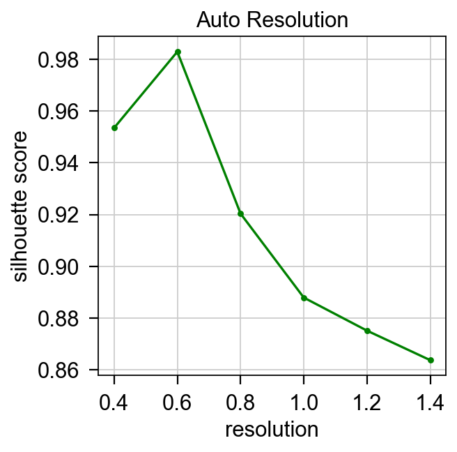

Don't forget to save your data

```python
results_file = os.path.join('./', 'scanpyobj.h5ad')
adata.write(results_file)
```

results_file = os.path.join('./', 'scanpyobj.h5ad') adata.write(results_file)

```python
results_file = os.path.join('./', 'scanpyobj.h5ad')
adata=sc.read(results_file)
```

results_file = os.path.join('./', 'scanpyobj.h5ad') adata=sc.read(results_file)

## IC50 predicted

Drug Response Prediction examined scanpyobj.h5ad generated in Single-Cell Data Analysis, reported clusterwise IC50 and cell death percentages to drugs in the GDSC database via CaDRReS-Sc (a recommender system framework for in silico drug response prediction), or drug sensitivity AUC in the PRISM database from [DepMap Portal PRISM-19Q4](https://doi.org/10.1038/s43018-019-0018-6).

Note we need to download the CaDRReS-Sc from github by `git clone https://github.com/CSB5/CaDRReS-Sc`

```python
!git clone https://github.com/CSB5/CaDRReS-Sc
```

!git clone https://github.com/CSB5/CaDRReS-Sc

```
Cloning into 'CaDRReS-Sc'...
remote: Enumerating objects: 378, done.
remote: Counting objects: 100% (9/9), done.
remote: Compressing objects: 100% (8/8), done.
remote: Total 378 (delta 4), reused 5 (delta 1), pack-reused 369
Receiving objects: 100% (378/378), 48.76 MiB | 2.75 MiB/s, done.
Resolving deltas: 100% (156/156), done.
```

To run drug response predicted, we need to set:

- scriptpath: the CaDRReS-Sc path we downloaded just now
- modelpath: the model path we downloaded just now
- output: the save path of drug response predicted result

```python
import ov
job=ov.single.Drug_Response(adata,scriptpath='CaDRReS-Sc',
                                modelpath='models/',
                                output='result')
```

import ov job=ov.single.Drug_Response(adata,scriptpath='CaDRReS-Sc', modelpath='models/', output='result')

```
Calculating kernel features based on 13738 common genes
(28385, 6) (17419, 1018)
Predicting drug response for using CaDRReS(GDSC): cadrres-wo-sample-bias
done!
Ploting...
done!
```